# PLNmodels: an R package for analyzing multivariate count data

In many fields of life science, count data is becoming the standard, like abundance table in ecology and microbiology, or single-cell data in molecular biology. The Poisson lognormal model is a latent model that describes the dependency structure of the data in an underlying Gaussian layer, while the observation layer of the count is Poisson distributed. As such, it offers the flexibility of the multivariate Gaussian distribution while preserving count distributions.  
In the R package **PLNmodels**, we implement an efficient variational strategy for inferring the standard Poisson lognormal model. We derive a series of model by transposing the classical tools from multivariate analysis, mostly tight to the Gaussian assumption of the data, to count data. **PLNmodels** includes variants for Principal Component Analysis, Discriminant Analysis, sparse inverse covariance estimation *a.k.a.* network inference and more coming, all designed for multivariate count data.

Julien Chiquet http://julien.cremeriefamily.info (MIA Paris, INRA)https://www6.inra.fr/mia-paris , Mahendra Mariadassou https://mahendra-mariadassou.github.io/ (MaIAGE, INRA)http://maiage.jouy.inra.fr/ , Stéphane Robin https://www6.inra.fr/mia-paris/Equipes/Membres/Stephane-Robin (MIA Paris, INRA)https://www6.inra.fr/mia-paris  
2018-12-11

## Introduction

In many fields of life science, count data is becoming the standard, like abundance table in ecology and microbiology, or single-cell data in molecular biology. Even if not explicitly stated, most of the standard tools of multivariate analysis (Principal component analysis, Linear Discriminant Analysis, multivariate linear regression or Gaussian Graphical Models, see e.g. (Mardia, Kent, and Bibby 1979)), assume a multivariate Gaussian distribution of the data. The goal of **PLNmodels** is to offer a set of functions based on the multivariate Poisson Lognormal (in short PLN) models to perform standard tasks of multivariate analysis with table of counts, thus in a non-Gaussian setting. For now, the top-level functions found in the package allow the user to perform the following analyses

[figure not shown]

- Multivariate Regression
- Dimension Reduction via probabilistic Poisson PCA
- Discriminant Analysis
- Structure Inference and sparse covariance estimation

### `trichoptera`: a motivating companion data set

The order Trichoptera (or caddisflies) are a group of insects with aquatic larvae and terrestrial adults. The ecological data set trichoptera (Usseglio-Polatera and Auda 1987) describes abundances of Trichopetera species (hereafter the *counts*), accompanied with some meteological factors (hereafter the *covariates*) that may have influenced their presence during the sampling[^1].

The data is directly available once **PLNmodels** is loaded. Comprehensive information and description are available to the user with `?PLNmodels::trichoptera`. Data are stored in the `trichoptera` data frame which includes 49 rows (the observations - or trapping nights) and 9 columns. There are 2 multivariate columns (matrices of counts and offsets) and 7 univariate columns (vectors of covariates).

```r
library(PLNmodels)
data(trichoptera)
```

#### Table of counts (abundancies)

The `Abundance` column is a $49 \times 17$ matrix of abundancies (or counts) for each 17 species during the 49 trapping nights

The count table is denoted by $\mathbf{Y}$ in the mathematical model and `Y` in the `R` environment

```r
trichoptera$Abundance %>% as.data.frame() %>% paged_table()
```

|  | Che | Hyc | Hym | Hys | Psy | Aga | Glo | Ath | Cea | Ced | Set | All | Han | Hfo | Hsp | Hve | Sta |
| --- | --- | --- | --- | --- | --- | --- | --- | --- | --- | --- | --- | --- | --- | --- | --- | --- | --- |
| 1 | 0 | 0 | 5 | 0 | 17 | 0 | 0 | 0 | 0 | 2 | 0 | 1 | 0 | 1 | 2 | 0 | 1 |
| 2 | 0 | 0 | 3 | 0 | 8 | 0 | 0 | 0 | 0 | 0 | 0 | 2 | 0 | 0 | 0 | 0 | 0 |
| 3 | 0 | 0 | 1 | 0 | 32 | 0 | 0 | 0 | 0 | 0 | 0 | 4 | 0 | 0 | 1 | 0 | 0 |
| 4 | 0 | 0 | 3 | 0 | 176 | 4 | 0 | 0 | 0 | 1 | 0 | 3 | 0 | 0 | 3 | 0 | 2 |
| 5 | 0 | 0 | 4 | 0 | 69 | 2 | 0 | 0 | 0 | 0 | 0 | 1 | 0 | 0 | 1 | 0 | 2 |
| 6 | 0 | 0 | 2 | 0 | 14 | 1 | 0 | 0 | 0 | 0 | 0 | 1 | 0 | 0 | 0 | 0 | 0 |
| 7 | 0 | 0 | 2 | 0 | 4 | 0 | 0 | 0 | 0 | 2 | 0 | 0 | 0 | 0 | 0 | 0 | 0 |
| 8 | 0 | 0 | 1 | 0 | 29 | 1 | 0 | 0 | 0 | 0 | 0 | 0 | 0 | 0 | 0 | 0 | 3 |
| 9 | 0 | 0 | 4 | 0 | 8 | 0 | 0 | 0 | 0 | 0 | 0 | 0 | 0 | 0 | 0 | 0 | 0 |
| 10 | 0 | 0 | 2 | 0 | 2 | 0 | 0 | 0 | 0 | 0 | 0 | 0 | 0 | 0 | 0 | 0 | 0 |

[output cut: 39 more lines]

#### Covariates (external meteorological effect, groups)

Additional information were collected during the sampling, which corresponds to external covariates the effect of which may or may not be taken into account in the model, depending on the question at play. In the trichoptera data set, those covariates correspond to meteorological factors plus a categorical variable indicating the family of the caughts specimens.

The design matrix arising from the covariates is denoted by $\mathbf{X}$ in the mathematical mdoel and `X` within the `R` environment.

```r
select(trichoptera, -TotalCounts, -Abundance) %>% paged_table()
```

|  | Temperature | Wind | Pressure | Humidity | Cloudiness | Precipitation | Group |
| --- | --- | --- | --- | --- | --- | --- | --- |
| 1 | 18.7 | -2.3 | 998.5 | 60 | 19 | 0.0 | 1 |
| 2 | 19.8 | -2.7 | 999.5 | 63 | 0 | 0.0 | 1 |
| 3 | 22.0 | -0.7 | 997.2 | 73 | 6 | 0.0 | 1 |
| 4 | 23.0 | 2.3 | 991.1 | 71 | 81 | 0.0 | 1 |
| 5 | 22.5 | 2.3 | 990.1 | 62 | 50 | 0.0 | 1 |
| 6 | 23.9 | -2.0 | 990.1 | 64 | 50 | 0.0 | 1 |
| 7 | 15.0 | -4.7 | 995.9 | 93 | 100 | 1.6 | 1 |
| 8 | 17.2 | -1.0 | 997.2 | 84 | 19 | 0.0 | 1 |
| 9 | 15.4 | -2.7 | 997.2 | 88 | 69 | 1.6 | 1 |
| 10 | 14.1 | -3.7 | 1001.0 | 75 | 6 | 0.0 | 1 |

[output cut: 39 more lines]

#### Compositionality issue, sampling effort and offsets

A common issue with (microbiological) ecological data is the compositionality problem: counts can only be compared to each other within a sample but not across samples as they depend on a sample-specific size-factor, which may induce spurious negative correlations of its own. Besides, the sampling of some particular species may be biased. Those technical biases can be encoded in a $49 \times 17$ matrix of offsets. In the case at hand, we have a natural offset observation that corresponds to the total counts per night, specified by a $49 \times 17$ matrix of offsets[^2] (matrix $\mathbf{O}$ in model). The corresponding column is named `TotalCounts` in the data frame:

Sampling effort or technical biaises are store in matrix $\mathbf{O}$ in the mathematical model and variable `O` in the `R` environment.

```r
trichoptera$TotalCounts %>% as.data.frame() %>% paged_table()
```

|  | Che | Hyc | Hym | Hys | Psy | Aga | Glo | Ath | Cea | Ced | Set | All | Han | Hfo | Hsp | Hve | Sta |
| --- | --- | --- | --- | --- | --- | --- | --- | --- | --- | --- | --- | --- | --- | --- | --- | --- | --- |
| 1 | 29 | 29 | 29 | 29 | 29 | 29 | 29 | 29 | 29 | 29 | 29 | 29 | 29 | 29 | 29 | 29 | 29 |
| 2 | 13 | 13 | 13 | 13 | 13 | 13 | 13 | 13 | 13 | 13 | 13 | 13 | 13 | 13 | 13 | 13 | 13 |
| 3 | 38 | 38 | 38 | 38 | 38 | 38 | 38 | 38 | 38 | 38 | 38 | 38 | 38 | 38 | 38 | 38 | 38 |
| 4 | 192 | 192 | 192 | 192 | 192 | 192 | 192 | 192 | 192 | 192 | 192 | 192 | 192 | 192 | 192 | 192 | 192 |
| 5 | 79 | 79 | 79 | 79 | 79 | 79 | 79 | 79 | 79 | 79 | 79 | 79 | 79 | 79 | 79 | 79 | 79 |
| 6 | 18 | 18 | 18 | 18 | 18 | 18 | 18 | 18 | 18 | 18 | 18 | 18 | 18 | 18 | 18 | 18 | 18 |
| 7 | 8 | 8 | 8 | 8 | 8 | 8 | 8 | 8 | 8 | 8 | 8 | 8 | 8 | 8 | 8 | 8 | 8 |
| 8 | 34 | 34 | 34 | 34 | 34 | 34 | 34 | 34 | 34 | 34 | 34 | 34 | 34 | 34 | 34 | 34 | 34 |
| 9 | 12 | 12 | 12 | 12 | 12 | 12 | 12 | 12 | 12 | 12 | 12 | 12 | 12 | 12 | 12 | 12 | 12 |
| 10 | 4 | 4 | 4 | 4 | 4 | 4 | 4 | 4 | 4 | 4 | 4 | 4 | 4 | 4 | 4 | 4 | 4 |

[output cut: 39 more lines]

## Statistical Framework

### The multivariate Poisson Lognormal model

The multivariate Poisson lognormal model (in short PLN, see (Aitchison and Ho 1989)) is the building block for all the multivariate models found in the **PLNmodels** package. It relates some $p$-dimensional observation vectors $\mathbf{Y}_i$ to some $p$-dimensional vectors of Gaussian latent variables $\mathbf{Z}_i$ as follows

$$\begin{equation}
\tag{1}
\begin{array}{rcl}
\text{latent space } & \mathbf{Z}_i \sim \mathcal{N}({\boldsymbol\mu},\boldsymbol\Sigma), \\
\text{observation space } & Y_{ij} | Z_{ij} \quad \text{indep.} & \mathbf{Y}_i | \mathbf{Z}_i\sim\mathcal{P}\left(\exp\{\mathbf{Z}_i\}\right).
\end{array}
\end{equation}$$

The parameter ${\boldsymbol\mu}$ corresponds to the main effects and the latent covariance matrix $\boldsymbol\Sigma$ describes the underlying structure of dependence between the $p$ variables. Figure 2 provides insights about the role played by the different layers

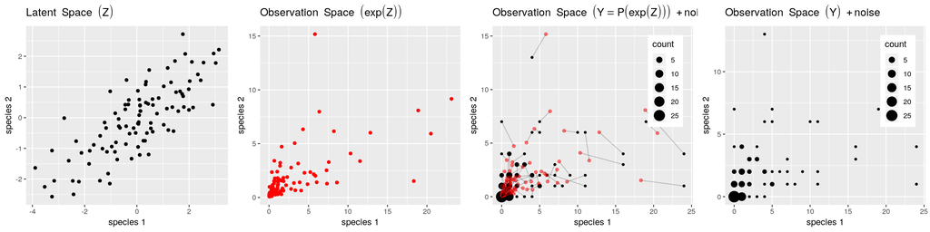

Figure 2: PLN: geometrical view

#### Acccounting for covariates and offsets in a GLM-like fashion

Count tables – like abundace data – often come with some external knowledge (via covariates and offsets) which should be taken into account during the fits. To this end, model generalizes naturally to a formulation closer to a multivariate generalized linear model, where the main effect is due to a linear combination of $d$ covariates $\mathbf{x}_i$. We also let the possibility to add some offsets for the $d$ variables and in each sample., that is $\mathbf{o}_i$. Hence, model (1) generalizes to

$$\begin{equation}
\tag{2}
\mathbf{Y}_i | \mathbf{Z}_i \sim \mathcal{P}\left(\exp\{\mathbf{Z}_i\}\right), \qquad \mathbf{Z}_i \sim \mathcal{N}({\mathbf{o}_i + \mathbf{x}_i^\top\boldsymbol\Theta},\boldsymbol\Sigma), \\
\end{equation}$$
where $\boldsymbol\Theta$ is a $d\times p$ matrix of regression parameters. When all individuals $i=1,\dots,n$ are stacked together, the data matrices available to feed the model are

#### GLM notation

We naturally recourse to the `R` `formulas` system to specified our model. A typical call to a a fitting function in **PLNmodels** uses formulas of the form

```r
Y ~ 1 + X1 + X2 + X1:X2 + offset(log(O))
```

where `Y` stands for the matrix of observed counts, `X1` and `X2` are two vector of covariates and `O` is a matrix of offsets with the same dimension as `Y`. Note the use of the `log` function *within* the `offset` function to specify the offset term, as it is the way with GLM-Poisson family of models.

### PLN variants

#### Sparse covariance estimation and network

In the PLN network, we penalized the inverse covariance $\boldsymbol\Sigma^{-1} = \boldsymbol\Theta$ by a $\ell_1$ penalty to induce sparsity and select important direct relationships between entities. Hence, the support of $\boldsymbol\Theta$ correspond to a network of underlying interactions. All mathematical details can be found in Chiquet, Mariadassou, and Robin (2018).

#### Principal Component Analysis

The model can be written in a hierachical framework where a sample of $p$-dimensional observation vectors $\mathbf{Y}_i$ is related to some $q$-dimensional vectors of latent variables $\mathbf{W}_i$ as follows
$$\begin{equation}
\label{eq:pca-model}
\begin{array}{rcl}
\text{latent space } & \mathbf{W}_i \quad \text{i.i.d.} & \mathbf{W}_i \sim \mathcal{N}(\mathbf{0}_q, \mathbf{I}_q) \\
\text{parameter space } & \mathbf{Z}_i = {\boldsymbol\mu} + \mathbf{B}^\top \mathbf{W}_i & \\
\text{observation space } & Y_{ij} | Z_{ij} \quad \text{indep.} & Y_{ij} | Z_{ij} \sim \mathcal{P}\left(\exp\{Z_{ij}\}\right)
\end{array}
\end{equation}$$

The parameter ${\boldsymbol\mu}$ corresponds to the main effects, $\mathbf{B}$ to loadings in the parameter spaces and $\mathbf{W}_i$ to scores of the $i$-th observation in the low-dimensional latent subspace of the parameter space. For more details, have a look at our research paper referenced in the package documentation.

The dimension of the latent space $q$ corresponds to the number of axes in the PCA or, in other words, to the rank of $\mathbf{B}\mathbf{B}^\intercal$.

## Author Contributions

Aitchison, J., and C.H. Ho. 1989. “The Multivariate Poisson-Log Normal Distribution.” *Biometrika* 76 (4). Oxford University Press: 643–53.

Chiquet, Julien, Mahendra Mariadassou, and Stéphane Robin. 2018. “Variational Inference for Sparse Network Reconstruction from Count Data.” *arXiv Preprint*. https://arxiv.org/abs/1806.03120.

Mardia, K.V., J.T. Kent, and J.M. Bibby. 1979. *Multivariate Analysis*. Academic press.

Usseglio-Polatera, P., and Y. Auda. 1987. “Influence Des Facteurs Météorologiques Sur Les Résultats de Piégeage Lumineux.” In *Annales de Limnologie-International Journal of Limnology*, 23:65–79. 1. EDP Sciences.

[^1]: The original version is available in the **ade4** package. We consider here a different version where we only keep a subset of the original meteorological features, for illutrative purposes
[^2]: Note that the offset term remains the same in a given sample albeit sometimes one might include an offset specific to both the sample and the species.